# Machine Learning: Entrega 1

Guillermo Sánchez-Cid Bueno

Los datos pertenecen al [paper](https://www.biorxiv.org/content/10.1101/2021.03.08.434412v1.full) facilitado por Juan Botía, profesor de la asignatura de Machine Learning del Máster de Bioinformática en la Universidad de Murcia (Curso 2021/2022).

```r
library(tidyverse)
```

```r
library(dplyr)
library(corrplot)
library(car)
library(ggplot2)
library(caret)
library(nortest)
library(RColorBrewer)
library(umap)
library(reshape2)
library(doParallel)
library(tidyr)
```

**Importarmos datos y visualizar estructura del dataset**

```r
registerDoParallel(cores = 10)

datos_completos <- readRDS(file = "dataPracticaML21_22.rds")

str(datos_completos)
```

```
## 'data.frame':    179968 obs. of  42 variables:
##  $ polyA_signal                : Factor w/ 2 levels "0","1": 2 2 2 2 1 2 2 2 2 2 ...
##  $ meanPd                      : num  186 178 189 191 182 ...
##  $ meanEE                      : num  0.973 0.963 0.968 0.945 0.972 ...
##  $ mean_phastCons7way          : num  0.315 0.693 0.692 0.13 0.423 ...
##  $ aphilicity                  : num  0.677 0.679 0.726 0.603 0.655 ...
##  $ basestacking                : num  -7.33 -7.44 -6.78 -7.89 -7.75 ...
##  $ bdnatwist                   : num  35.7 36 35.9 35.5 36 ...
##  $ bendability                 : num  -0.03027 -0.00512 -0.03967 -0.01489 -0.02072 ...
##  $ bendingstiffness            : num  54.2 55.9 45.9 66.8 62 ...
##  $ cpgislands                  : num  0.0714 0.1317 0.0682 0.1296 0.1116 ...
##  $ cpnpgcpgislands             : num  0.144 0.211 0.106 0.242 0.227 ...
##  $ cpnpgislands                : num  0.246 0.205 0.118 0.346 0.361 ...
##  $ dnadenaturation             : num  79.1 80 74.9 84.6 82.4 ...
##  $ duplexstabilitydisruptenergy: num  1.78 1.83 1.71 1.97 1.89 ...
```

[output cut: 28 more lines]

# Análisis exploratorio de los datos

Se trata de un dataset con 42 variables y 179968 entradas que representan características genómicas y de expresión génica sobre data de RNA-seq obtenida del proyecto GTEx (Genotype-Tissue Expression Consortium). A priori, parece ser que hay varios “grupos” de variables: propiedades topológicas, propiedades termodinámicas y características de la secuencia de bases nitrogenas per se.

```r
levels(datos_completos$class)
```

```
## [1] "5-UTR"      "ICE"        "lncRNA"     "ncRNA"      "pseudoGene"
## [6] "UTR"
```

Hay dos variables tratadas como factores. La primera es polyA_signal que representa dos niveles que indican presencia o ausencia de este motivo en la secuencia. El otro es clase, un factor con 6 niveles que corresponden a regiones del genoma: 5-UTR (5’UTR - 5’ side untranslated region), ICE (internal coding exons), lncRNA (long non-coding RNAs), ncRNA (non-coding RNAs), pseudoGene y UTR (3’UTR - 3’ side untranslated region). El resto son variables numéricas.

Cambiamos las etiquetas de las clases de la variable polyA_signal para que sea más informativa.

```r
datos_completos$polyA_signal <- as.factor(Recode(datos_completos$polyA_signal,
                                         "0 = 'NO'; 1 = 'YES'"))
```

A continución, vamos a comprobar si las varibables del dataset están en la misma escala.

```r
variables_numericas <- as.numeric(which(sapply(datos_completos,class) == "numeric"))
#Se utiliza la función melt para poder crear un dataframe apto para poder hacer un Box and Whisker plot con el paquete ggplot2
datos_completos_melt = melt(datos_completos[,variables_numericas], variable.name = "Variable")
```

Para ello, realizaremos un Box and Whisker plot para observar como se distribuyen los datos en función de las diferentes variables:

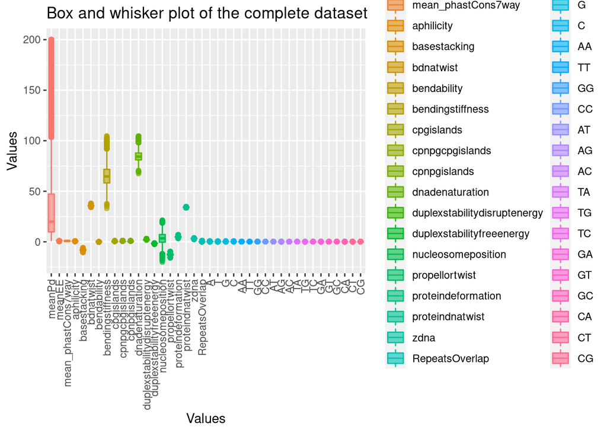

```r
ggplot(data=datos_completos_melt, aes(x=Variable, y=value, color=Variable, fill=Variable)) +
  geom_boxplot(alpha=0.6) +
  scale_fill_discrete() +
  scale_color_discrete() +
  ggtitle("Box and whisker plot of the complete dataset") +
  ylab("Values") +
  xlab("Values") + theme(axis.text.x = element_text(angle = 90, vjust = 0.5, hjust=1))
```

Como se puede apreciar, tenemos unas cuantas variables numéricas que no están en la misma escala que el resto y convendría escalarlas; eso sí, sin distorsionar las diferencias en los intervalos de valores ni perder información. Este paso es importante porque a la hora de trabajar con datos a diferentes escalas podría generar problemas al intentar combinar valores como características durante el modelado. Es por ello que muchos algortimos de machine learning requieren datos escalados y centrados para procesarlos de una forma correcta.

```r
#Utilizamos la función preProcess de caret para centrar y escalar las variables numéricas del dataset
variables_numericas <- as.numeric(which(sapply(datos_completos,class) == "numeric"))
escalado_y_centrado <- preProcess(datos_completos[,variables_numericas], method = c("center", "scale"))
dataset_escalado <-predict(escalado_y_centrado,datos_completos[,variables_numericas])
```

Ahora sí, todos los datos están escalados y centrados:

```r
#Se utiliza la función melt para poder crear un dataframe apto para poder hacer un Box and Whisker plot con el paquete ggplot2
datos_escalados_melt = melt(dataset_escalado, variable.name = "Variable")
str(datos_escalados_melt)
```

```
## 'data.frame':    7198720 obs. of  2 variables:
##  $ Variable: Factor w/ 40 levels "meanPd","meanEE",..: 1 1 1 1 1 1 1 1 1 1 ...
##  $ value   : num  2.31 2.18 2.36 2.39 2.24 ...
```

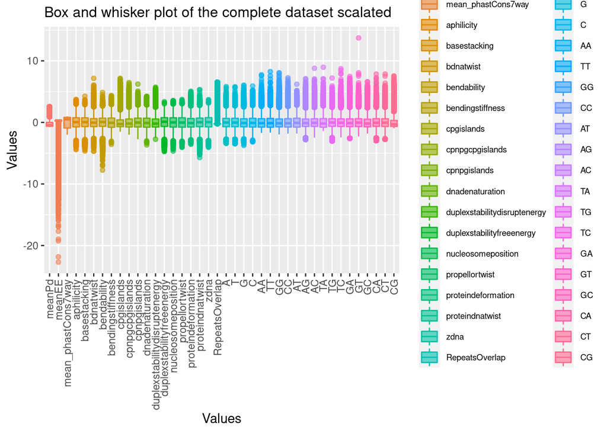

```r
ggplot(data=datos_escalados_melt, aes(x=Variable, y=value, color=Variable, fill=Variable)) +
  geom_boxplot(alpha=0.6) +
  scale_fill_discrete() +
  scale_color_discrete() +
  ggtitle("Box and whisker plot of the complete dataset scalated") +
  ylab("Values") +
  xlab("Values") + theme(axis.text.x = element_text(angle = 90, vjust = 0.5, hjust=1), legend.text=element_text(size=7), plot.title=element_text(size=12))
```

### 3.1 ¿Nos enfrentamos a un problema balanceado o no balanceado? ¿Qué implicaciones tiene esto en la resolución de la práctica?

Las muestras de las clases que pertenecen al factor class y se distribuyen de la siguiente manera:

```r
table(datos_completos$class)
```

```
##
##      5-UTR        ICE     lncRNA      ncRNA pseudoGene        UTR
##      21798     130768       3718       3819       2146      17719
```

Nos encontramos ante un dataset no balanceado ya que hay muchas entradas para algunas clases (5-UTR, ICE y UTR) y pocas para las otras clases (lncRNA, ncRNA y pseudoGene). Como no está balanceado, hay que tener especial atención a los datos menos numerosos. La principal implicación que esto tiene es que el modelo que creemos posteriormente estará sesgado hacia las clases mayoritarias. Por lo tanto, si implementamos un modelo sin tener este aspecto en cuenta puede producir predicciones falsas y conclusiones erróneas, algo que puede ser nefasto en investigaciones tan sensibles como detección de cáncer u otras enfermedades.

Veamos la distribución de clases de una manera más ilustrativa:

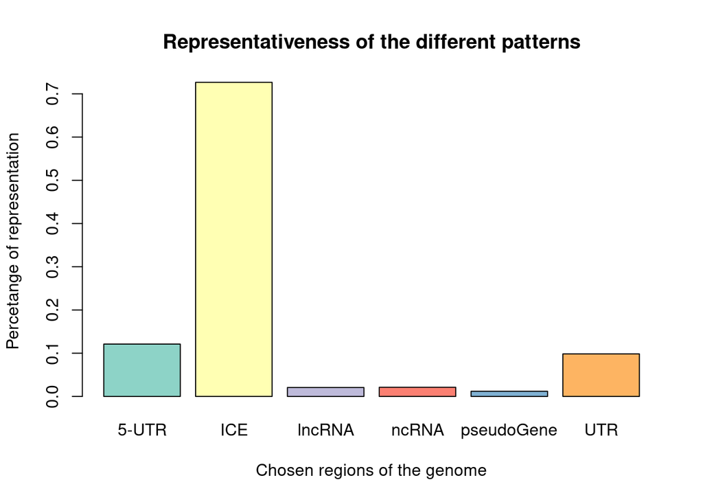

```r
library(RColorBrewer)
barplot(prop.table(table(datos_completos$class)), main = "Representativeness of the different patterns",
     xlab = "Chosen regions of the genome", ylab = "Percetange of representation",
     col = brewer.pal(6, "Set3"))
```

Como podemos observar, el porcentaje de representación de la clase más numerosa es de alrededor del 70% (ICE), seguida de la segunda clase más representativa, con un 10-12% (5-UTR). Esto demuestra el gran desequilibrio en la representación entre la clase más representativa y el resto.

### 3.2 ¿Hay valores nulos? Si los hay, ¿cómo tratarlos?

```r
anyNA.data.frame(datos_completos, recursive = TRUE)
```

```
## [1] FALSE
```

```r
any(!complete.cases(datos_completos))
```

```
## [1] FALSE
```

No se han reportado valores no disponibles en este dataset. Si los hubiera, se estudia la distribución de los mismos. Es importante averiguar si estos valores ausentes se distribuyen de manera aleatoria o si existe un patrón, ya que si su distribución no fuese aleatoria a lo largo de todo el conjunto de datos la representatividad de la muestra sobre la que estaríamos trabajando se vería muy afectada. Para el tratamiento de los NA (not available) tenemos dos opciones: eliminar las muestras que tienen estos datos ausentes o imputar dichos valores mediante estimaciones.

### 3.3 ¿Hay correlación entre predictores? Visualizar e identificar posibles correlaciones validándolas mediante el test estadístico correspondiente. ¿Hay correlaciones muy altas? ¿Cómo podríamos usar esto en los análisis corrientes abajo?

Con el fin de estudiar la correlación de predictores, utilizaremos el objeto dataset_escalado el cual no tiene los factores ya que no podemos introducir variables categóricas en un test de correlación. Para este caso, he utilzado el cálculo de correlaciones de Pearson, que nos servirá para posteriores análisis como ACP o UMAP. Además, con esta información también podemos detectar cuáles son las variables altamente correladas y, si es conveniente, eliminarlas.

```r
#Correlaciones de Pearson
cor.matrix = cor(dataset_escalado)
saveRDS(cor.matrix,"./cor.matrix.rds")
```

```r
cor.matrix=readRDS("cor.matrix.rds")
```

Observemos una representación de la matriz de correlaciones de Pearson mediante el paquete corrplot. Este método de visualización nos permite detectar patrones de una manera bastante sencilla.

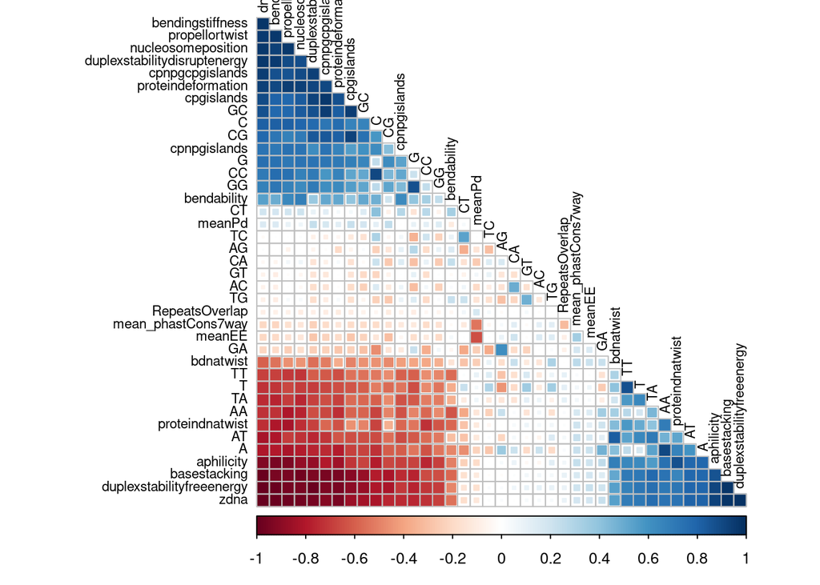

```r
corrplot::corrplot(cor.matrix, tl.cex = 0.7, tl.col = "black", method = 'square', order = 'FPC', type = 'lower', diag = FALSE)
```

Como se puede observar, exiten correlaciones fuertes entre un gran número de predictores.Lo que corresponde ahora es comprobar si existe causalidad.

A continuación, vamos a realizar un test para validar correlación. Para ello, podemos aplicar un test sobre el coeficiente de correlación de Pearson de las muestras (asumiendo que las muestras siguen una distribución normal). Hay que tener en cuenta que las conclusiones que se pueden sacar de un test como este depende mucho de la naturaleza de los datos con los que estemos trabajando. Es decir, cuando trabajamos con muestras de estudios de expresión génica (como es nuestro caso), debemos tener en cuenta correlaciones que, aunque parezcan muy débiles, si son significativas o cerca de serlo, debemos considerarlas en este y otros análisis posteriores. El motivo es que si las descartamos, podríamos estar perdiendo información de gran valor que ayude a explicar el comportamiento del conjunto de los datos.

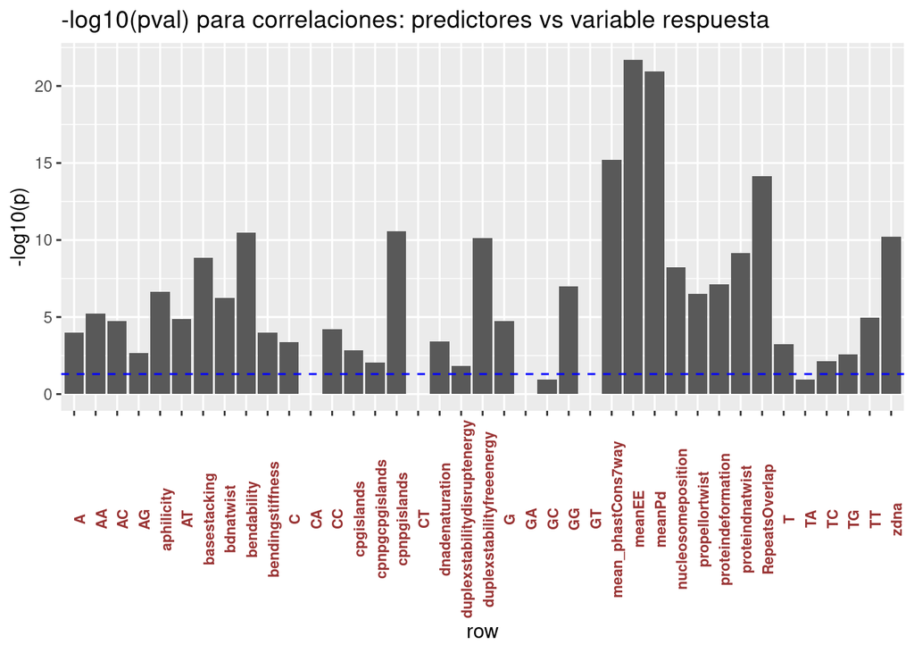

```r
matrix_shaping=function(correlmatrix, p_values){
ut=upper.tri(cor.matrix)
data.frame(row=rownames(correlmatrix)[row(correlmatrix)[ut]],
           column=rownames(correlmatrix)[col(correlmatrix)[ut]],
           p=p_values[ut])
}

# Ejecutamos la función usando la matriz de correlación como los argumentos y almacenamos los pvalores obtenidos
matrixdf = matrix_shaping(cor.matrix,cor.matrix)



#Graficamos
ggplot(data=matrixdf) + aes(x=row,y=-log10(p)) +
  geom_col() + geom_hline(yintercept = -log10(0.05),
                             col="blue",linetype="dashed") +
  labs(title="-log10(pval) para correlaciones: predictores vs variable respuesta",
       ylab="-log10(pval)",xlab="predictores") + theme(axis.text.x = element_text(face="bold", color="#993333", size=8, angle=90))
```

#### Eliminación de las variables altamente correlacionadas

```r
check_cor_pearson <- caret::findCorrelation(cor.matrix, cutoff=0.9, verbose=TRUE, names=TRUE); check_cor_pearson
```

```
## Compare row 12  and column  14 with corr  0.992
##   Means:  0.604 vs 0.4 so flagging column 12
## Compare row 14  and column  19 with corr  0.99
##   Means:  0.593 vs 0.389 so flagging column 14
## Compare row 19  and column  8 with corr  0.984
##   Means:  0.576 vs 0.378 so flagging column 19
## Compare row 8  and column  13 with corr  0.956
##   Means:  0.564 vs 0.368 so flagging column 8
## Compare row 13  and column  5 with corr  0.93
##   Means:  0.552 vs 0.357 so flagging column 13
## Compare row 5  and column  16 with corr  0.941
##   Means:  0.534 vs 0.345 so flagging column 5
## Compare row 16  and column  15 with corr  0.967
##   Means:  0.518 vs 0.334 so flagging column 16
## Compare row 15  and column  17 with corr  0.934
##   Means:  0.498 vs 0.324 so flagging column 15
## Compare row 10  and column  17 with corr  0.905
##   Means:  0.486 vs 0.313 so flagging column 10
## Compare row 9  and column  37 with corr  0.942
##   Means:  0.444 vs 0.302 so flagging column 9
## Compare row 21  and column  25 with corr  0.907
##   Means:  0.449 vs 0.293 so flagging column 21
## Compare row 24  and column  28 with corr  0.903
##   Means:  0.434 vs 0.283 so flagging column 24
## All correlations <= 0.9
```

```
##  [1] "dnadenaturation"              "duplexstabilityfreeenergy"
##  [3] "zdna"                         "bendingstiffness"
##  [5] "duplexstabilitydisruptenergy" "basestacking"
##  [7] "propellortwist"               "nucleosomeposition"
##  [9] "cpnpgcpgislands"              "cpgislands"
## [11] "A"                            "C"
```

Mediante la función findCorrelation, buscamos en la matriz de correlaciones variables altamente correladas con respecto al resto de variables y nos devuelve un vector con los índices que corresponden a las variables que deberíamos retirar para reducir la correlación por pares de acuerdo con el umbral que establezcamos. Para este caso, se ha establecido como umbral superior un correlación del 0.9 para tratar de eliminar solo las variables con un nivel de correlación muy alto.

```r
#Eliminamos del dataset las variables con una correlación superior al 0.9
dataset_cor_filtered = select(dataset_escalado, -all_of(check_cor_pearson))
str(dataset_cor_filtered)
```

```
## 'data.frame':    179968 obs. of  28 variables:
##  $ meanPd            : num  2.31 2.18 2.36 2.39 2.24 ...
##  $ meanEE            : num  -0.498 -0.832 -0.654 -1.381 -0.524 ...
##  $ mean_phastCons7way: num  -1.059 0.0687 0.0659 -1.6116 -0.7368 ...
##  $ aphilicity        : num  0.808 0.85 1.696 -0.526 0.408 ...
##  $ bdnatwist         : num  0.0498 0.6866 0.418 -0.7443 0.6897 ...
##  $ bendability       : num  -0.845 0.716 -1.428 0.11 -0.252 ...
##  $ cpnpgislands      : num  -0.957 -1.254 -1.876 -0.248 -0.14 ...
##  $ proteindeformation: num  -1.065 -0.922 -1.836 -0.325 -0.487 ...
##  $ proteindnatwist   : num  0.7198 0.1858 1.4309 -0.8491 -0.0869 ...
##  $ RepeatsOverlap    : num  0.254 -0.225 -0.225 0.887 6.511 ...
##  $ T                 : num  1.593 1.359 2.475 0.477 1.071 ...
##  $ G                 : num  -1.131 -1.411 -1.818 -0.466 -0.204 ...
##  $ AA                : num  0.59 0.4322 1.0061 -0.2985 -0.0508 ...
##  $ TT                : num  1.359 0.732 2.464 0.192 0.672 ...
##  $ GG                : num  -0.9437 -0.4982 -1.2909 -0.0244 -0.0235 ...
##  $ CC                : num  -0.741 -0.476 -1.208 0.567 -0.311 ...
##  $ AT                : num  0.988 1.547 2.194 -0.321 0.593 ...
##  $ AG                : num  -0.877 -1.096 -0.915 -0.253 -0.382 ...
##  $ AC                : num  -0.122 -0.803 -1.064 -0.044 -1.284 ...
##  $ TA                : num  1.739 2.116 3.355 0.499 0.275 ...
##  $ TG                : num  0.471 -0.029 -0.684 -0.2 0.925 ...
##  $ TC                : num  0.0313 0.873 -0.6617 0.7334 0.8394 ...
##  $ GA                : num  -0.811 -1.546 -1.269 -0.862 -0.508 ...
##  $ GT                : num  1.147 -0.819 0.497 0.375 0.851 ...
##  $ GC                : num  -0.984 0.0186 -1.0734 -0.3318 -0.3843 ...
##  $ CA                : num  -0.688 -0.153 -1.173 -0.14 -0.449 ...
##  $ CT                : num  0.163 1.478 -0.951 1.059 0.613 ...
##  $ CG                : num  -0.762 -0.952 -0.716 -0.583 -0.819 ...
```

Añadimos de nuevo los factores para seguir trabajando con el dataset al que le hemos hecho el tratamiento previo.

```r
filtered_data_scalated <- cbind("polyA_signal"= datos_completos[,1], dataset_cor_filtered,"class" = datos_completos[,42])
saveRDS(filtered_data_scalated,"./filtered_data_scalated.rds")
```

```r
filtered_data_scalated=readRDS("filtered_data_scalated.rds")
```

### 3.4 ¿Hay alguna asociación lineal entre predictores y alguno de los tipos de región (5’, 3’ UTRs, lncRNAs, ncRANs, pseudo genes e ICE)?

Para buscar asociaciones lineales entre las variables numéricas y nuestra categórica, la variable Class debe ser tratada como una variables respuesta binaria para simplificar el análisis. El modelo apropiado para estos casos es el modelo de regresión logístico. Realizaremos 6 regresiones logísticas en las que la variable respuesta será clasificada en dos grupos: una clase y el resto de clases.

```r
str(filtered_data_scalated)
```

```
## 'data.frame':    179968 obs. of  30 variables:
##  $ polyA_signal      : Factor w/ 2 levels "NO","YES": 2 2 2 2 1 2 2 2 2 2 ...
##  $ meanPd            : num  2.31 2.18 2.36 2.39 2.24 ...
##  $ meanEE            : num  -0.498 -0.832 -0.654 -1.381 -0.524 ...
##  $ mean_phastCons7way: num  -1.059 0.0687 0.0659 -1.6116 -0.7368 ...
##  $ aphilicity        : num  0.808 0.85 1.696 -0.526 0.408 ...
##  $ bdnatwist         : num  0.0498 0.6866 0.418 -0.7443 0.6897 ...
##  $ bendability       : num  -0.845 0.716 -1.428 0.11 -0.252 ...
##  $ cpnpgislands      : num  -0.957 -1.254 -1.876 -0.248 -0.14 ...
##  $ proteindeformation: num  -1.065 -0.922 -1.836 -0.325 -0.487 ...
##  $ proteindnatwist   : num  0.7198 0.1858 1.4309 -0.8491 -0.0869 ...
##  $ RepeatsOverlap    : num  0.254 -0.225 -0.225 0.887 6.511 ...
##  $ T                 : num  1.593 1.359 2.475 0.477 1.071 ...
##  $ G                 : num  -1.131 -1.411 -1.818 -0.466 -0.204 ...
##  $ AA                : num  0.59 0.4322 1.0061 -0.2985 -0.0508 ...
```

[output cut: 16 more lines]

Eliminamos el factor “polyA_signal” para realizar las regresiones logísticas. El motivo es que la regresión no admite otro factor que no sea con el que se está clasificando.

```r
set.seed(111)
dataset_cor_filtered_no_polyA <-filtered_data_scalated[,2:30]
```

#### Modelo de regresión logístico 5UTR versus No-UTR5

```r
model_5UTR = glm(formula = dataset_cor_filtered_no_polyA$class == "5-UTR" ~ ., family = binomial(link = "logit"),
    data = dataset_cor_filtered_no_polyA)

saveRDS(model_5UTR,"./model_5UTR.rds")
```

```r
model_5UTR <- readRDS(file = "model_5UTR.rds")
summary(model_5UTR)
```

```
##
## Call:
## glm(formula = dataset_cor_filtered_no_polyA$class == "5-UTR" ~
##     ., family = binomial(link = "logit"), data = dataset_cor_filtered_no_polyA)
##
## Deviance Residuals:
##     Min       1Q   Median       3Q      Max
## -3.9927  -0.3437  -0.1981  -0.1147   3.8758
##
## Coefficients:
##                      Estimate Std. Error  z value Pr(>|z|)
## (Intercept)        -3.094e+00  1.457e-02 -212.361  < 2e-16 ***
## meanPd              3.735e-01  1.191e-02   31.368  < 2e-16 ***
## meanEE             -3.027e-01  9.788e-03  -30.923  < 2e-16 ***
## mean_phastCons7way -7.387e-01  1.094e-02  -67.512  < 2e-16 ***
## aphilicity          1.791e+02  8.770e+00   20.420  < 2e-16 ***
## bdnatwist          -1.190e+01  3.440e+00   -3.458 0.000545 ***
## bendability        -1.818e-01  3.004e-02   -6.053 1.43e-09 ***
## cpnpgislands        4.933e-02  1.754e-02    2.813 0.004908 **
## proteindeformation  7.586e+01  2.990e+00   25.370  < 2e-16 ***
## proteindnatwist    -9.181e+01  4.758e+00  -19.296  < 2e-16 ***
## RepeatsOverlap      4.869e-02  7.393e-03    6.586 4.51e-11 ***
## T                   1.133e+00  1.085e-01   10.443  < 2e-16 ***
## G                  -1.080e-02  7.957e-02   -0.136 0.891998
## AA                 -2.152e-01  5.127e-02   -4.198 2.69e-05 ***
## TT                  2.140e-01  4.597e-02    4.655 3.24e-06 ***
## GG                 -2.295e-01  3.876e-02   -5.922 3.18e-09 ***
## CC                 -3.516e-01  4.208e-02   -8.354  < 2e-16 ***
## AT                 -1.029e+02  3.992e+00  -25.782  < 2e-16 ***
## AG                 -2.219e+01  2.532e+00   -8.764  < 2e-16 ***
## AC                 -7.727e+00  1.107e+00   -6.979 2.96e-12 ***
## TA                  6.126e+01  2.712e+00   22.585  < 2e-16 ***
## TG                  1.345e+01  1.775e+00    7.575 3.59e-14 ***
## TC                  2.227e+01  1.945e+00   11.453  < 2e-16 ***
## GA                  2.536e+01  2.399e+00   10.569  < 2e-16 ***
## GT                 -9.032e+00  1.071e+00   -8.433  < 2e-16 ***
## GC                 -2.067e+01  6.135e-01  -33.696  < 2e-16 ***
## CA                  1.160e+01  1.760e+00    6.592 4.34e-11 ***
## CT                 -2.194e+01  2.257e+00   -9.720  < 2e-16 ***
## CG                  1.481e+01  1.227e+00   12.072  < 2e-16 ***
## ---
## Signif. codes:  0 '***' 0.001 '**' 0.01 '*' 0.05 '.' 0.1 ' ' 1
##
## (Dispersion parameter for binomial family taken to be 1)
##
##     Null deviance: 132872  on 179967  degrees of freedom
## Residual deviance:  74279  on 179939  degrees of freedom
## AIC: 74337
##
## Number of Fisher Scoring iterations: 6
```

Casi todas las variables son significativas excepto G.

#### Modelo de regresión logístico ICE versus No-ICE

```r
model_ICE = glm(dataset_cor_filtered_no_polyA$class=="ICE" ~ .,data=dataset_cor_filtered_no_polyA, family=binomial(link="logit"))

saveRDS(model_ICE,"./model_ICE.rds")
```

```r
model_ICE <- readRDS(file = "model_ICE.rds")
summary(model_ICE)
```

```
##
## Call:
## glm(formula = dataset_cor_filtered_no_polyA$class == "ICE" ~
##     ., family = binomial(link = "logit"), data = dataset_cor_filtered_no_polyA)
##
## Deviance Residuals:
##     Min       1Q   Median       3Q      Max
## -3.8792  -0.0563   0.1714   0.2929   4.0428
##
## Coefficients:
##                      Estimate Std. Error z value Pr(>|z|)
## (Intercept)          1.668499   0.012025 138.749  < 2e-16 ***
## meanPd              -1.749107   0.018443 -94.841  < 2e-16 ***
## meanEE               0.197789   0.024506   8.071 6.96e-16 ***
## mean_phastCons7way   1.358303   0.010549 128.761  < 2e-16 ***
## aphilicity         -35.588081   9.554886  -3.725 0.000196 ***
## bdnatwist            0.371229   3.689674   0.101 0.919858
## bendability         -0.066896   0.029500  -2.268 0.023348 *
## cpnpgislands         0.073302   0.017807   4.116 3.85e-05 ***
## proteindeformation -38.354404   3.249314 -11.804  < 2e-16 ***
## proteindnatwist     10.403452   5.212683   1.996 0.045956 *
## RepeatsOverlap      -0.511335   0.011624 -43.990  < 2e-16 ***
## T                   -1.295138   0.105341 -12.295  < 2e-16 ***
## G                    1.074300   0.084999  12.639  < 2e-16 ***
## AA                   0.477079   0.048389   9.859  < 2e-16 ***
## TT                   0.265614   0.043491   6.107 1.01e-09 ***
## GG                   0.126430   0.041251   3.065 0.002177 **
## CC                   0.954352   0.044017  21.682  < 2e-16 ***
## AT                   7.122327   4.462245   1.596 0.110460
## AG                  -3.593456   2.753677  -1.305 0.191904
## AC                  -5.686323   1.220452  -4.659 3.17e-06 ***
## TA                  -2.701220   3.015187  -0.896 0.370321
## TG                  13.288621   1.984176   6.697 2.12e-11 ***
## TC                  -0.037039   2.111404  -0.018 0.986004
## GA                   0.001247   2.603375   0.000 0.999618
## GT                  -5.312993   1.180644  -4.500 6.79e-06 ***
## GC                   0.356257   0.682698   0.522 0.601784
## CA                  13.475483   1.966808   6.851 7.31e-12 ***
## CT                  -2.420251   2.456092  -0.985 0.324424
## CG                  17.464615   1.501695  11.630  < 2e-16 ***
## ---
## Signif. codes:  0 '***' 0.001 '**' 0.01 '*' 0.05 '.' 0.1 ' ' 1
##
## (Dispersion parameter for binomial family taken to be 1)
##
##     Null deviance: 211136  on 179967  degrees of freedom
## Residual deviance:  69624  on 179939  degrees of freedom
## AIC: 69682
##
## Number of Fisher Scoring iterations: 7
```

#### Modelo de regresión logístico lncRNA versus No-lncRNA

```r
model_lncRNA = glm(dataset_cor_filtered_no_polyA$class=="lncRNA" ~ .,data=dataset_cor_filtered_no_polyA, family=binomial(link="logit"))
saveRDS(model_lncRNA,"./model_lncRNA.rds")
```

```r
model_lncRNA <- readRDS(file = "model_lncRNA.rds")
summary(model_lncRNA)
```

```
##
## Call:
## glm(formula = dataset_cor_filtered_no_polyA$class == "lncRNA" ~
##     ., family = binomial(link = "logit"), data = dataset_cor_filtered_no_polyA)
##
## Deviance Residuals:
##     Min       1Q   Median       3Q      Max
## -1.7816  -0.1503  -0.0670  -0.0485   4.4099
##
## Coefficients:
##                      Estimate Std. Error  z value Pr(>|z|)
## (Intercept)         -5.480070   0.044483 -123.194  < 2e-16 ***
## meanPd              -0.173967   0.021906   -7.942 2.00e-15 ***
## meanEE              -0.046542   0.015545   -2.994 0.002754 **
## mean_phastCons7way  -1.588335   0.029423  -53.982  < 2e-16 ***
## aphilicity         -58.232086  23.199085   -2.510 0.012070 *
## bdnatwist            0.922853   9.258891    0.100 0.920605
## bendability          0.218680   0.062849    3.479 0.000502 ***
## cpnpgislands        -0.135332   0.038142   -3.548 0.000388 ***
## proteindeformation -68.407883   7.974258   -8.579  < 2e-16 ***
## proteindnatwist     14.420535  12.694646    1.136 0.255976
## RepeatsOverlap       0.369383   0.007638   48.360  < 2e-16 ***
## T                   -1.163047   0.238672   -4.873 1.10e-06 ***
## G                    1.011483   0.192387    5.258 1.46e-07 ***
## AA                   0.402096   0.102081    3.939 8.18e-05 ***
## TT                   0.149950   0.095574    1.569 0.116664
## GG                  -0.129234   0.091170   -1.418 0.156336
## CC                   0.369139   0.097075    3.803 0.000143 ***
## AT                   5.924014  10.754920    0.551 0.581758
## AG                  -9.384351   6.838840   -1.372 0.169997
## AC                 -10.372321   3.052463   -3.398 0.000679 ***
## TA                  -2.085610   7.299159   -0.286 0.775083
## TG                  23.787611   5.001101    4.756 1.97e-06 ***
## TC                   1.717788   5.216442    0.329 0.741927
## GA                   1.714535   6.436329    0.266 0.789944
## GT                 -10.099164   2.952192   -3.421 0.000624 ***
## GC                   2.616502   1.620858    1.614 0.106469
## CA                  23.535071   4.958741    4.746 2.07e-06 ***
## CT                  -7.731438   6.097471   -1.268 0.204807
## CG                  30.570503   3.898037    7.843 4.42e-15 ***
## ---
## Signif. codes:  0 '***' 0.001 '**' 0.01 '*' 0.05 '.' 0.1 ' ' 1
##
## (Dispersion parameter for binomial family taken to be 1)
##
##     Null deviance: 36207  on 179967  degrees of freedom
## Residual deviance: 24898  on 179939  degrees of freedom
## AIC: 24956
##
## Number of Fisher Scoring iterations: 8
```

En este modelo es llamativo que hay muchas menos variables significativas en comparación a los modelos anteriores. Las variables que no significativas son: bdnatwist, proteindnatwist, TT, GG, AT, AG TA TC GA, GC y CT. Es interesante mencionar que, al igual que el modelo de ICE, las variables que no son significativas están relacionadas con el orden de las bases nitogenadas en la secuencia.

#### Modelo de regresión logístico ncRNA versus No-ncRNA

```r
model_ncRNA = glm(dataset_cor_filtered_no_polyA$class=="ncRNA" ~ .,data=dataset_cor_filtered_no_polyA, family=binomial(link="logit"))
saveRDS(model_ncRNA,"./model_ncRNA.rds")
```

```r
model_ncRNA <- readRDS(file = "model_ncRNA.rds")
summary(model_ncRNA)
```

```
##
## Call:
## glm(formula = dataset_cor_filtered_no_polyA$class == "ncRNA" ~
##     ., family = binomial(link = "logit"), data = dataset_cor_filtered_no_polyA)
##
## Deviance Residuals:
##     Min       1Q   Median       3Q      Max
## -3.0398  -0.1672  -0.0912  -0.0557   4.3994
##
## Coefficients:
##                      Estimate Std. Error  z value Pr(>|z|)
## (Intercept)          -5.23107    0.03462 -151.101  < 2e-16 ***
## meanPd               -0.32902    0.02317  -14.202  < 2e-16 ***
## meanEE               -0.22996    0.01302  -17.663  < 2e-16 ***
## mean_phastCons7way   -1.19766    0.02132  -56.188  < 2e-16 ***
## aphilicity          216.31121   13.94943   15.507  < 2e-16 ***
## bdnatwist           -55.52498    5.48373  -10.125  < 2e-16 ***
## bendability          -0.17682    0.05102   -3.466 0.000528 ***
## cpnpgislands         -0.41662    0.03156  -13.201  < 2e-16 ***
## proteindeformation  101.65620    4.64414   21.889  < 2e-16 ***
## proteindnatwist    -108.20674    7.66554  -14.116  < 2e-16 ***
## RepeatsOverlap        0.06417    0.01026    6.255 3.97e-10 ***
## T                     2.46877    0.18011   13.707  < 2e-16 ***
## G                    -2.07534    0.15254  -13.605  < 2e-16 ***
## AA                    0.14218    0.09248    1.537 0.124206
## TT                    0.22191    0.07080    3.134 0.001723 **
## GG                    0.18941    0.07400    2.560 0.010480 *
## CC                   -1.70371    0.08224  -20.715  < 2e-16 ***
## AT                  -89.80959    6.57830  -13.652  < 2e-16 ***
## AG                  -42.79646    4.13117  -10.359  < 2e-16 ***
## AC                  -14.92305    1.85228   -8.057 7.85e-16 ***
## TA                   59.29665    4.46266   13.287  < 2e-16 ***
## TG                   17.02400    3.04029    5.599 2.15e-08 ***
## TC                   35.15531    3.15121   11.156  < 2e-16 ***
## GA                   46.61967    3.87857   12.020  < 2e-16 ***
## GT                  -12.49691    1.79256   -6.972 3.13e-12 ***
## GC                  -11.13532    0.98472  -11.308  < 2e-16 ***
## CA                   19.16658    3.00977    6.368 1.91e-10 ***
## CT                  -36.48491    3.68454   -9.902  < 2e-16 ***
## CG                   -5.60412    2.30973   -2.426 0.015253 *
## ---
## Signif. codes:  0 '***' 0.001 '**' 0.01 '*' 0.05 '.' 0.1 ' ' 1
##
## (Dispersion parameter for binomial family taken to be 1)
##
##     Null deviance: 36984  on 179967  degrees of freedom
## Residual deviance: 25753  on 179939  degrees of freedom
## AIC: 25811
##
## Number of Fisher Scoring iterations: 8
```

Todos son significativos exceptuando AA. En este modelo logístico que permite distinguir la clase “ncRNA” del resto, las variables que describen el contenido nucleico nucleico parecen tener mayor importancia que en el caso del modelo para las secuencias “lncRNA”.

#### Modelo de regresión logístico pseudoGene versus No-pseudoGene

```r
model_pseudoGene = glm(dataset_cor_filtered_no_polyA$class=="pseudoGene" ~ .,data=dataset_cor_filtered_no_polyA, family=binomial(link="logit"))
saveRDS(model_pseudoGene,"./model_pseudoGene.rds")
```

```r
model_pseudoGene <- readRDS(file = "model_pseudoGene.rds")
summary(model_pseudoGene)
```

```
##
## Call:
## glm(formula = dataset_cor_filtered_no_polyA$class == "pseudoGene" ~
##     ., family = binomial(link = "logit"), data = dataset_cor_filtered_no_polyA)
##
## Deviance Residuals:
##     Min       1Q   Median       3Q      Max
## -0.6656  -0.1656  -0.1248  -0.1039   3.8129
##
## Coefficients:
##                     Estimate Std. Error  z value Pr(>|z|)
## (Intercept)         -4.70984    0.02737 -172.060  < 2e-16 ***
## meanPd               0.11496    0.02870    4.006 6.18e-05 ***
## meanEE              -0.03255    0.02088   -1.559  0.11900
## mean_phastCons7way  -0.59132    0.02563  -23.074  < 2e-16 ***
## aphilicity          35.39050   25.52236    1.387  0.16555
## bdnatwist          -13.11237   10.06361   -1.303  0.19259
## bendability          0.01019    0.06979    0.146  0.88395
## cpnpgislands        -0.02156    0.04171   -0.517  0.60521
## proteindeformation  -9.83177    8.55765   -1.149  0.25060
## proteindnatwist    -26.05983   14.04283   -1.856  0.06349 .
## RepeatsOverlap       0.12581    0.01301    9.669  < 2e-16 ***
## T                   -0.38763    0.26357   -1.471  0.14138
## G                    0.52871    0.21814    2.424  0.01536 *
## AA                  -0.10639    0.11431   -0.931  0.35201
## TT                   0.07096    0.10590    0.670  0.50282
## GG                   0.16013    0.10165    1.575  0.11519
## CC                   0.50543    0.10855    4.656 3.22e-06 ***
## AT                 -28.30371   12.04296   -2.350  0.01876 *
## AG                 -16.83132    7.54396   -2.231  0.02567 *
## AC                 -10.33725    3.39081   -3.049  0.00230 **
## TA                  19.24798    8.15525    2.360  0.01827 *
## TG                  20.33816    5.58334    3.643  0.00027 ***
## TC                  11.22655    5.74340    1.955  0.05062 .
## GA                  13.49621    7.08592    1.905  0.05683 .
## GT                 -10.20079    3.27939   -3.111  0.00187 **
## GC                  -4.43542    1.79835   -2.466  0.01365 *
## CA                  19.91655    5.53432    3.599  0.00032 ***
## CT                 -14.94067    6.72416   -2.222  0.02629 *
## CG                  19.89792    4.38675    4.536 5.74e-06 ***
## ---
## Signif. codes:  0 '***' 0.001 '**' 0.01 '*' 0.05 '.' 0.1 ' ' 1
##
## (Dispersion parameter for binomial family taken to be 1)
##
##     Null deviance: 23276  on 179967  degrees of freedom
## Residual deviance: 21915  on 179939  degrees of freedom
## AIC: 21973
##
## Number of Fisher Scoring iterations: 8
```

Para el modelo de regresión logístico de la clase pseudoGene. Es llamativo que esta sea la clase con menos predictores significativos. La mayoría de los predictores significativos están relacionados están relacionados con la distribución de las bases nitrogenadas. La mayoría de los predictores que no son significativos para el modelo están relacionados con propiedades físicas de la secuencia; especialmente, con su topología.

En este modelo ocurre un fenómeno a tener en cuenta: hay predictores que no son significativos al tener un p-valor por encima de 0.05 pero esta muy cerca de serlo ya que sus p-valores son inferiores a 0.1, por lo que hay que prestarles atención debido a la naturaleza de los datos (expresión génica), ya que aunque no sean significativos aportan información al modelo y si los descatársemos, podríamos estar perdiendo información importante para explicar el modelo.

#### Modelo de regresión logístico UTR versus No-UTR

```r
model_UTR = glm(dataset_cor_filtered_no_polyA$class=="UTR" ~ .,data=dataset_cor_filtered_no_polyA, family=binomial(link="logit"))
saveRDS(model_UTR,"./model_UTR.rds")
```

```r
model_UTR <- readRDS(file = "model_UTR.rds")
summary(model_UTR)
```

```
##
## Call:
## glm(formula = dataset_cor_filtered_no_polyA$class == "UTR" ~
##     ., family = binomial(link = "logit"), data = dataset_cor_filtered_no_polyA)
##
## Deviance Residuals:
##     Min       1Q   Median       3Q      Max
## -3.2280  -0.1472  -0.0701  -0.0288   6.1206
##
## Coefficients:
##                      Estimate Std. Error  z value Pr(>|z|)
## (Intercept)        -5.028e+00  3.269e-02 -153.833  < 2e-16 ***
## meanPd              1.509e+00  1.631e-02   92.557  < 2e-16 ***
## meanEE              5.345e-01  1.356e-02   39.424  < 2e-16 ***
## mean_phastCons7way -9.058e-01  1.752e-02  -51.690  < 2e-16 ***
## aphilicity         -4.581e+02  1.683e+01  -27.217  < 2e-16 ***
## bdnatwist           1.239e+02  6.792e+00   18.241  < 2e-16 ***
## bendability         3.999e-01  5.316e-02    7.522 5.41e-14 ***
## cpnpgislands        2.416e-02  3.292e-02    0.734  0.46297
## proteindeformation -2.307e+02  6.324e+00  -36.476  < 2e-16 ***
## proteindnatwist     2.182e+02  9.151e+00   23.845  < 2e-16 ***
## RepeatsOverlap     -7.366e-03  9.169e-03   -0.803  0.42177
## T                  -3.659e+00  1.881e-01  -19.451  < 2e-16 ***
## G                  -1.463e+00  1.609e-01   -9.093  < 2e-16 ***
## AA                 -1.045e+00  8.686e-02  -12.027  < 2e-16 ***
## TT                 -8.918e-01  7.269e-02  -12.268  < 2e-16 ***
## GG                 -2.502e-01  8.106e-02   -3.086  0.00203 **
## CC                 -9.995e-01  8.230e-02  -12.145  < 2e-16 ***
## AT                  1.626e+02  7.926e+00   20.511  < 2e-16 ***
## AG                  7.655e+01  4.898e+00   15.629  < 2e-16 ***
## AC                  2.183e+01  2.205e+00    9.898  < 2e-16 ***
## TA                 -1.095e+02  5.319e+00  -20.579  < 2e-16 ***
## TG                 -2.698e+01  3.662e+00   -7.369 1.72e-13 ***
## TC                 -7.272e+01  3.741e+00  -19.438  < 2e-16 ***
## GA                 -8.724e+01  4.621e+00  -18.878  < 2e-16 ***
## GT                  2.394e+01  2.125e+00   11.269  < 2e-16 ***
## GC                  2.425e+01  1.279e+00   18.969  < 2e-16 ***
## CA                 -2.527e+01  3.638e+00   -6.945 3.78e-12 ***
## CT                  7.114e+01  4.362e+00   16.310  < 2e-16 ***
## CG                  2.395e+01  3.372e+00    7.102 1.23e-12 ***
## ---
## Signif. codes:  0 '***' 0.001 '**' 0.01 '*' 0.05 '.' 0.1 ' ' 1
##
## (Dispersion parameter for binomial family taken to be 1)
##
##     Null deviance: 115784  on 179967  degrees of freedom
## Residual deviance:  36400  on 179939  degrees of freedom
## AIC: 36458
##
## Number of Fisher Scoring iterations: 8
```

Casi todas las variables son significativas excepto cpnpgislands y RepeatsOverlap.

### 3.5 De entre las variables que, a priori, se han identificado como interesantes por su relación con la variable de clase, ¿Se distribuyen de forma normal? ¿Presentan valores fuera de rango?

```r
names(filtered_data_scalated)
```

```
##  [1] "polyA_signal"       "meanPd"             "meanEE"
##  [4] "mean_phastCons7way" "aphilicity"         "bdnatwist"
##  [7] "bendability"        "cpnpgislands"       "proteindeformation"
## [10] "proteindnatwist"    "RepeatsOverlap"     "T"
## [13] "G"                  "AA"                 "TT"
## [16] "GG"                 "CC"                 "AT"
## [19] "AG"                 "AC"                 "TA"
## [22] "TG"                 "TC"                 "GA"
## [25] "GT"                 "GC"                 "CA"
## [28] "CT"                 "CG"                 "class"
```

```r
#Se utiliza la función melt para poder crear un dataframe apto para poder hacer un Box and Whisker plot con el paquete ggplot2
data_melt = melt(dataset_cor_filtered_no_polyA, variable.name = "Variable")
```

Tras todo el procesado del conjunto de datos, nos hemos quedado con las siguientes variables:

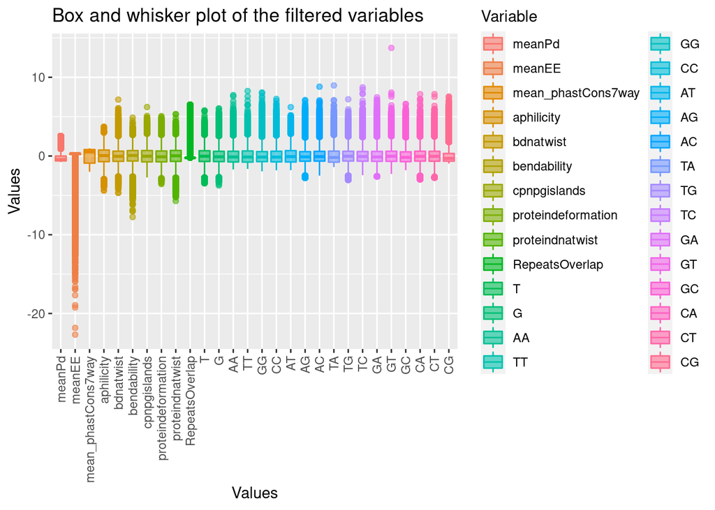

```r
ggplot(data=data_melt, aes(x=Variable, y=value, color=Variable, fill=Variable)) +
  geom_boxplot(alpha=0.6) +
  scale_fill_discrete() +
  scale_color_discrete() +
  ggtitle("Box and whisker plot of the filtered variables") +
  ylab("Values") +
  xlab("Values") + theme(axis.text.x = element_text(angle = 90, vjust = 0.5, hjust=1))
```

Como se puede apreciar, existen valores fuera de rango o outliers para la gran mayoría de las variables. Si queremos conservarlos para no perder esa información y continuar el estudio con ellos, debemos tenerlos presentes a la hora de evaluar los resultados ya que estos valores pueden afectar sensiblemente los futuros análisis y el tratamiento de los datos. En la gráfica se puede observar que a pesar de que pueda parecer que la población pueda seguir una distribución normal para la mayoría de las variables, todas las distribuciones parecen tener colas muy largas que pueden indicar que, aunque puedan asemejarse a distribuciones normales, es bastente probable que no lo sean. Para comprobar si las variables siguen una distribución normal, utilizaremos el test de Kolmogorov-Smirnov con la adaptación, el test de Lilliefors, que está indicado para un conjunto de muestras gran tamaño.

```r
library(nortest)
apply(dataset_cor_filtered, MARGIN = 2, lillie.test)
```

```
## $meanPd
##
##  Lilliefors (Kolmogorov-Smirnov) normality test
##
## data:  newX[, i]
## D = 0.26951, p-value < 2.2e-16
##
##
## $meanEE
##
##  Lilliefors (Kolmogorov-Smirnov) normality test
##
## data:  newX[, i]
## D = 0.36345, p-value < 2.2e-16
##
##
## $mean_phastCons7way
##
##  Lilliefors (Kolmogorov-Smirnov) normality test
##
## data:  newX[, i]
## D = 0.20073, p-value < 2.2e-16
##
##
## $aphilicity
##
##  Lilliefors (Kolmogorov-Smirnov) normality test
##
## data:  newX[, i]
## D = 0.034607, p-value < 2.2e-16
##
##
## $bdnatwist
##
##  Lilliefors (Kolmogorov-Smirnov) normality test
##
## data:  newX[, i]
## D = 0.023746, p-value < 2.2e-16
##
##
```

[output cut: 167 more lines]

```
##
## $CT
##
##  Lilliefors (Kolmogorov-Smirnov) normality test
##
## data:  newX[, i]
## D = 0.030768, p-value < 2.2e-16
##
##
## $CG
##
##  Lilliefors (Kolmogorov-Smirnov) normality test
##
## data:  newX[, i]
## D = 0.17047, p-value < 2.2e-16
```

Según el test de Lilliefors (Kolmogorov-Smirnov), y en función de cada variable numérica, las observaciones provienen de una población no distribuida normalmente.

### 3.6 ¿Qué nos dice un análisis no supervisado de la separabilidad de las regiones?

Para el análisis no supervisado, haremos uso del análisis de componentes principales (PCA) con el objetivo de estudiar la separabilidad de las variables. Para ello utilizaremos el data frame filtered_data_scaled cuyas principales características eran las siguientes:

```r
str(filtered_data_scalated)
```

```
## 'data.frame':    179968 obs. of  30 variables:
##  $ polyA_signal      : Factor w/ 2 levels "NO","YES": 2 2 2 2 1 2 2 2 2 2 ...
##  $ meanPd            : num  2.31 2.18 2.36 2.39 2.24 ...
##  $ meanEE            : num  -0.498 -0.832 -0.654 -1.381 -0.524 ...
##  $ mean_phastCons7way: num  -1.059 0.0687 0.0659 -1.6116 -0.7368 ...
##  $ aphilicity        : num  0.808 0.85 1.696 -0.526 0.408 ...
##  $ bdnatwist         : num  0.0498 0.6866 0.418 -0.7443 0.6897 ...
##  $ bendability       : num  -0.845 0.716 -1.428 0.11 -0.252 ...
##  $ cpnpgislands      : num  -0.957 -1.254 -1.876 -0.248 -0.14 ...
##  $ proteindeformation: num  -1.065 -0.922 -1.836 -0.325 -0.487 ...
##  $ proteindnatwist   : num  0.7198 0.1858 1.4309 -0.8491 -0.0869 ...
##  $ RepeatsOverlap    : num  0.254 -0.225 -0.225 0.887 6.511 ...
##  $ T                 : num  1.593 1.359 2.475 0.477 1.071 ...
##  $ G                 : num  -1.131 -1.411 -1.818 -0.466 -0.204 ...
##  $ AA                : num  0.59 0.4322 1.0061 -0.2985 -0.0508 ...
```

[output cut: 16 more lines]

Realizamos el PCA mediante la función prcomp la cual nos devuelve un objeto que es una lista con la clase “prcomp” con los siguientes componentes:

```r
pca_result <- prcomp(dataset_cor_filtered[,2:ncol(dataset_cor_filtered)], scale = TRUE)
names(pca_result)
saveRDS(pca_result,"./pca_result.rds")
```

```r
pca_result <- readRDS(file = "pca_result.rds")
```

Los resultados que muestran los componentes principales obtenidos a partir del dataset están almacenados en el componente “x”

```r
pcas = as.data.frame(pca_result$x,stringsAsFactors=F)
```

A continuación representaremos el análisis de los dos primeros componentes principales, los que retienen la mayor cantidad de información para explicar el conjunto de datos. Recordemos que el dataset que hemos utilizado está escalado y tiene la selección de variables ya mencionada anteriormente. Sin embargo, no está balanceado. Eso quiere decir que la representación de las clases del factor Class no poseen el mismo número de muestras, lo que puede hacer que unas clases se superpongan encima de otras y nos impida observar con claridad el resto de clases.

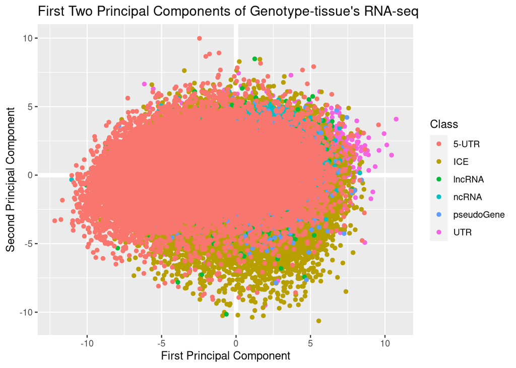

```r
pcasplusclass = cbind(Class = datos_completos$class,pcas)
ggplot(pcasplusclass, aes(PC1, PC2, color=Class, fill=Class)) +
  modelr::geom_ref_line(h = 0) +
  modelr::geom_ref_line(v = 0) +
  geom_point() +
  xlab("First Principal Component") +
  ylab("Second Principal Component") +
  ggtitle("First Two Principal Components of Genotype-tissue's RNA-seq ")
```

Por otro lado, si decidieramos recurrir a otro tipo de representaciones como UMAP o t-SNE para intentar una representación gráfica más avanzada, nos encontraríamos con el mismo problema.

Existen varias técnicas para balancear el conjunto de datos y así mejorar las representaciones gráficas. La técnica que vamos a utilizar es Downsamplig y consiste en disminuir el número de muestras de las clases en función de la cantidad de muestras de la clase menos representada (en este caso, pseudoGene). El paquete caret ofrece una función llamada downSample que sirve para nuestro propósito.

```r
set.seed(111)
balanced_data <-downSample(x=filtered_data_scalated[,-ncol(filtered_data_scalated)], y=filtered_data_scalated$class)

# str(balanced_class)
table(balanced_data$Class)
```

```
##
##      5-UTR        ICE     lncRNA      ncRNA pseudoGene        UTR
##       2146       2146       2146       2146       2146       2146
```

Ahora tenemos las clases balanceadas, por lo que podemos realizar unas gráficas para los dos primeros componentes principales y un umap más ilustrativo.

```r
pca_result2 <- prcomp(balanced_data[,2:29], scale = TRUE)
saveRDS(pca_result2,"./pca_result2.rds")
```

```r
pca_result2 <- readRDS(file = "pca_result2.rds")
```

```r
pcas2 = as.data.frame(pca_result2$x,stringsAsFactors=F)
str(pcas2)
```

```
## 'data.frame':    12876 obs. of  28 variables:
##  $ PC1 : num  -1.712 4.963 4.313 -0.254 7.537 ...
##  $ PC2 : num  -1.065 1.862 -0.492 0.282 -0.477 ...
##  $ PC3 : num  0.447 -0.796 -1.371 0.204 -2.6 ...
##  $ PC4 : num  -1.929 1.284 -1.762 0.175 0.766 ...
##  $ PC5 : num  0.722 0.631 -2.162 -0.989 0.891 ...
##  $ PC6 : num  -0.621 0.333 -1.079 -0.709 0.636 ...
##  $ PC7 : num  -0.445 1.724 -0.148 -0.243 0.227 ...
##  $ PC8 : num  0.232 -0.226 0.281 -1.989 -1.314 ...
##  $ PC9 : num  0.707 0.26 -0.593 0.183 0.27 ...
##  $ PC10: num  -1.703 0.187 1.223 -0.788 0.519 ...
##  $ PC11: num  -0.6715 0.52585 0.99681 0.85711 -0.00281 ...
##  $ PC12: num  0.398 0.396 0.488 -0.562 0.575 ...
##  $ PC13: num  -0.525 -0.347 0.762 -0.885 0.962 ...
##  $ PC14: num  -0.581 -0.585 1.12 1.109 0.419 ...
##  $ PC15: num  0.2616 0.4072 -0.0389 -0.3461 -0.45 ...
##  $ PC16: num  0.378 -0.565 -0.56 -0.193 -0.327 ...
##  $ PC17: num  0.477 -0.307 -0.328 0.125 0.312 ...
##  $ PC18: num  -0.0475 -0.2152 0.1458 0.0471 0.0568 ...
##  $ PC19: num  0.2784 0.118 0.0302 0.4504 0.0566 ...
##  $ PC20: num  0.1749 -0.0542 0.0539 -0.3248 0.0277 ...
##  $ PC21: num  0.2554 -0.0431 -0.1517 -0.0438 0.0445 ...
##  $ PC22: num  0.0451 -0.0258 0.0347 -0.0219 0.0387 ...
##  $ PC23: num  -0.0021 0.079 -0.0864 -0.0522 -0.0219 ...
##  $ PC24: num  0.08042 0.00009 -0.00958 -0.06289 -0.0248 ...
##  $ PC25: num  -0.0414 0.0188 -0.0674 0.1402 0.0296 ...
##  $ PC26: num  0.00435 0.00216 -0.00151 -0.00547 0.00863 ...
##  $ PC27: num  -0.001026 0.002393 0.004408 0.000217 0.005897 ...
##  $ PC28: num  2.62e-05 -2.41e-04 2.14e-04 1.29e-04 -3.82e-04 ...
```

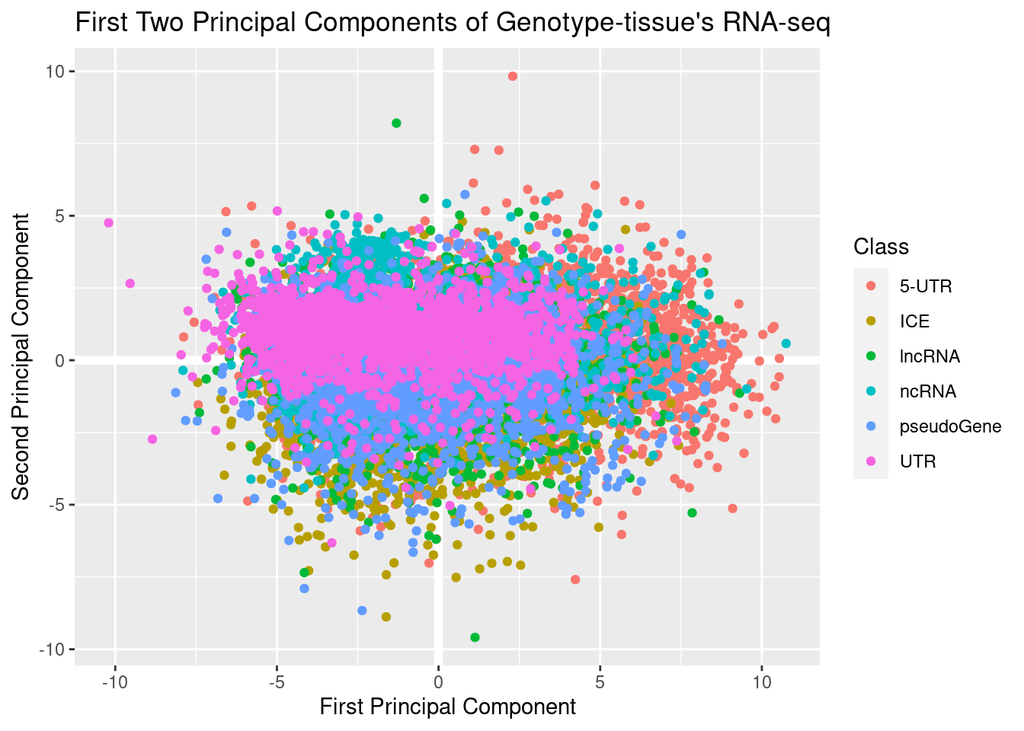

```r
pcasplusclass = cbind(Class = balanced_data$Class,pcas2)
ggplot(pcasplusclass, aes(PC1, PC2, color=Class, fill=Class)) +
  modelr::geom_ref_line(h = 0) +
  modelr::geom_ref_line(v = 0) +
  geom_point() +
  xlab("First Principal Component") +
  ylab("Second Principal Component") +
  ggtitle("First Two Principal Components of Genotype-tissue's RNA-seq ")
```

Ha mejorado la representación, pero seguimos si poder observar una separación clara de clases.

```r
umap_result <- umap(balanced_data[,2:29])
saveRDS(umap_result,"./umap_result.rds")
```

```r
umap_result <- readRDS(file = "umap_result.rds")
```

```r
colnames(umap_result$layout) = c("UMAP1","UMAP2")
umapaxes = as.data.frame(umap_result$layout,stringsAsFactors=F)
```

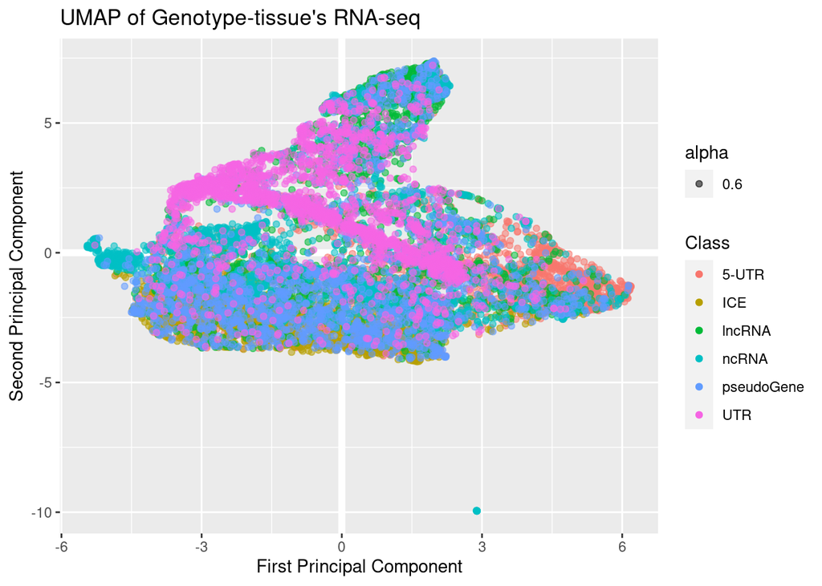

```r
umapaxes_a = cbind(Class = balanced_data$Class,umapaxes)
ggplot(umapaxes_a, aes(UMAP1, UMAP2, color=Class,fill=Class, alpha=0.6)) +
  modelr::geom_ref_line(h = 0) +
  modelr::geom_ref_line(v = 0) +

  geom_point() + scale_shape(solid=F) +
  xlab("First Principal Component") +
  ylab("Second Principal Component") +
  ggtitle("UMAP of Genotype-tissue's RNA-seq")
```

###Conclusión del análisis exploratorio

La exploración de los datos, el estudio de su distribución, y su posible relación con la variable respuesta parecen indicar que los predictores que más información aportan a explicar el conjunto de los datos son las siguientes:

```r
names(filtered_data_scalated)
```

```
##  [1] "polyA_signal"       "meanPd"             "meanEE"
##  [4] "mean_phastCons7way" "aphilicity"         "bdnatwist"
##  [7] "bendability"        "cpnpgislands"       "proteindeformation"
## [10] "proteindnatwist"    "RepeatsOverlap"     "T"
## [13] "G"                  "AA"                 "TT"
## [16] "GG"                 "CC"                 "AT"
## [19] "AG"                 "AC"                 "TA"
## [22] "TG"                 "TC"                 "GA"
## [25] "GT"                 "GC"                 "CA"
## [28] "CT"                 "CG"                 "class"
```

# Selección de variables

####Se pide, empleando una de las técnicas vistas en clase para selección de variables, elaborar un informe con los predictores más apropiados para usar en la generación de modelos predictores para la pregunta a responder. Se ha de justificar la elección de la técnica adecuadamente.

####En este apartado se deberá describir por qué se ha elegido la técnica usada, cómo se configura para usarla, y un análisis crítico de los resultados, tanto dese el punto de vista de análisis de datos como desde el biológico.

Filtramos el dataset inicial y quitamos las variables con varianza cercana a cero para eliminar aquellas variables que no aportan prácticamente nada a explicar el conjunto de los datos.

```r
nzv <- nzv(filtered_data_scalated)
data_var_selection_filtered <- filtered_data_scalated[,-nzv]
saveRDS(data_var_selection_filtered,"./data_var_selection_filtered.rds")
```

```r
data_var_selection_filtered=readRDS("data_var_selection_filtered.rds")
nzv
```

[output not shown]

```r
names(filtered_data_scalated[11])
```

```
## [1] "RepeatsOverlap"
```

La variable eliminada del dataset corresponde a “RepeatsOverlap”, relacionada con la coincidencia a nivel de bases nucleotídicas entre dos secuencias de material genético.

## Modelos utilizados

### Eliminación Recursiva de variables

Necesitamos crear un objeto de control que defina alguno de los parámetros del proceso de selección de hiperparámetros y parámetros: método de validación, número de folds o pligues, la semilla de alatoriedad y otros parámetros opcionales. Para este algoritmo, se ha decidido utilizar una validación cruzada de diez pliegues o folds.

```r
subsets <- c(3:20) #solo busca entre 3 y 20 variables.

set.seed(123) #semilla de aleatorización

ctrl.treebag.rfe.cv.10_filtrado <- rfeControl(functions=treebagFuncs, #clasificador para evaluar los conjuntos de variables
                                     method = "cv",
                                     number = 10,
                                     seeds = NULL,
                                     returnResamp="final",
                                     verbose = TRUE,
                                     allowParallel = TRUE)
```

A la hora de ejutar el algoritmo treebagFuncs mediante la función rfe de caret (eliminador recursivo de features), especificamos el tamaño de los subsets, incluimos el control que hemos creado en el paso previo y lo lanzamos.

```r
set.seed(123)
treebag.rfe.cv.10_filtrado <- rfe(class~., data=data_var_selection_filtered,
                         sizes=subsets,
                         rfeControl=ctrl.treebag.rfe.cv.10_filtrado)
saveRDS(treebag.rfe.cv.10_filtrado, "treebag_rfe_cv_10_datos_todos.rds")
```

```r
treebag.rfe.cv.10_filtrado=readRDS(file = "./treebag_rfe_cv_10_datos_todos.rds")
```

```r
treebag.rfe.cv.10_filtrado
```

```
##
## Recursive feature selection
##
## Outer resampling method: Cross-Validated (10 fold)
##
## Resampling performance over subset size:
##
##  Variables Accuracy  Kappa AccuracySD  KappaSD Selected
##          3   0.8242 0.5776   0.001644 0.005158
##          4   0.8562 0.6555   0.001894 0.005022
##          5   0.8687 0.6857   0.001507 0.004247
##          6   0.8740 0.6978   0.001346 0.003656
##          7   0.8768 0.7044   0.001469 0.003584
##          8   0.8779 0.7069   0.001909 0.004752
##          9   0.8799 0.7114   0.001326 0.003688
##         10   0.8832 0.7200   0.001753 0.004600
##         11   0.8846 0.7230   0.001764 0.004177
##         12   0.8846 0.7233   0.001544 0.004105
##         13   0.8850 0.7239   0.001583 0.003980
##         14   0.8859 0.7261   0.002003 0.004699
##         15   0.8862 0.7265   0.001180 0.003182
##         16   0.8869 0.7285   0.001986 0.004862
##         17   0.8872 0.7289   0.002110 0.005203
##         18   0.8873 0.7293   0.001378 0.003518
##         19   0.8880 0.7307   0.001561 0.004000
##         20   0.8884 0.7318   0.001873 0.004842
##         21   0.8878 0.7304   0.001575 0.003562
##         22   0.8884 0.7316   0.001768 0.004171
##         23   0.8892 0.7337   0.001793 0.004477
##         24   0.8891 0.7333   0.002139 0.005311
##         25   0.8893 0.7337   0.001510 0.003780        *
##         28   0.8892 0.7335   0.001811 0.004364
##
## The top 5 variables (out of 25):
##    meanPd, meanEE, mean_phastCons7way, polyA_signalYES, CG
```

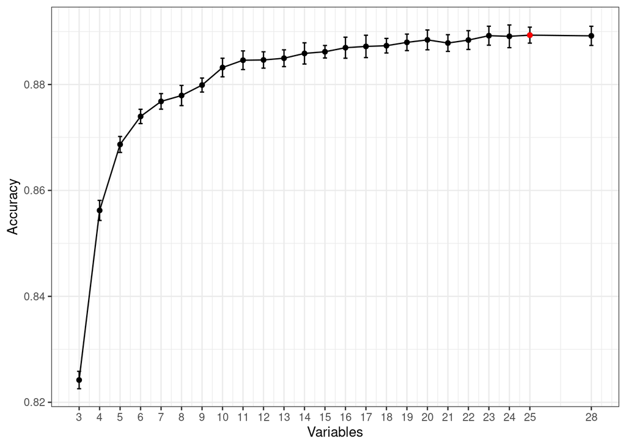

```r
ggplot(data = treebag.rfe.cv.10_filtrado$results, aes(x = Variables, y = Accuracy)) +
  geom_line() +
  scale_x_continuous(breaks  = unique(treebag.rfe.cv.10_filtrado$results$Variables)) +
  geom_point() +
  geom_errorbar(aes(ymin = Accuracy - AccuracySD, ymax = Accuracy + AccuracySD),
                width = 0.2) +
  geom_point(data = treebag.rfe.cv.10_filtrado$results %>% slice(which.max(Accuracy)),
             color = "red") +
  theme_bw()
```

La gráfica nos indica que el mayor accuracy se obtiene con 25 variables; sin embargo, si observamos la gráfica, esta empieza a estabilizarse el valor de accuracy con 20 variables y después disminuye y aumenta hasta alcanzar el máximo con 25 variables. Si nos fijamos en la tabla anterior al gráfico, este máximo valor de accuracy no dista mucho del obtenido con 20 variables. Eso nos indica que con la selección de 20 variable podríamos trabajar y no estaríamos perdiendo casi nada de eficacia en nuestro modelo, por lo que seguiríamos teniendo un modelo representativo. Adicionalmente, este modelo nos indica las cinco mejores variables: meanPd, meanEE, mean_phastCons7way, polyA_signalYES y CG.

### Selección de variables por filtros

Como se ha mencionado anteriormente, además de la eli eliminación recursiva, vamos a utilizar el método de selección por filtro para poder tener otro modelo de referencia y así seleccionar features y comparar y elegir el que mejor rendimiento nos ofrezca. Para ello, usaremos la función sbf de caret (seleccionador de features por filtrado) y haremos un proceso parecido al modelo anterior.

```r
set.seed(123)
#Pliegues
folds = 10

#Semillas de aleatoriedad
seeds <- sample.int(1000,folds +1)

#Control
ctrl.ranker.cv.10 <- sbfControl(functions = treebagSBF,
                                method = "cv", number = folds,
                                seeds = seeds)
set.seed(234)
treebag.ranker.cv.10 <- sbf(class~., data=data_var_selection_filtered,
                            sbfControl = ctrl.ranker.cv.10)
```

```r
treebag.ranker.cv.10=readRDS(file = "./treebag_ranker_cv_10_datos_todos.rds")
treebag.ranker.cv.10
```

```
##
## Selection By Filter
##
## Outer resampling method: Cross-Validated (10 fold)
##
## Resampling performance:
##
##  Accuracy  Kappa AccuracySD  KappaSD
##    0.8897 0.7349   0.002232 0.005784
##
## Using the training set, 28 variables were selected:
##    polyA_signalYES, meanPd, meanEE, mean_phastCons7way, aphilicity...
##
## During resampling, the top 5 selected variables (out of a possible 28):
##    AA (100%), AC (100%), AG (100%), aphilicity (100%), AT (100%)
##
## On average, 28 variables were selected (min = 28, max = 28)
```

Del conjunto de variables, el modelo de selección por filtros nos selecciona las 28 variables, es decir, todas son importantes y no descarta ninguna. Por otro lado las cinco variables que el modelo considera con las mejores son: AA, AC, AG, aphilicity y AT. Como se puede apreciar, las variables top 5 del modelo de eliminación recursiva son totalmente diferentes a las 5 mejores variables del modelo de selección por filtros. Aunque se haya utilizado el mismo método de validación (validación cruzada) y en las mismas condiciones (10 folds), los algoritmos tienen mecánicas diferentes y obtienes resultados muy distintos.

### Selección de variables por búsqueda aleatoria: algoritmos genéticos.

Este tipo de algoritmos de selección de variables es de tipo wrapper, es decir, necesita que definamos el modelo predictivo que va a evaluar los subconjuntos. Lo que cambia respecto a al eliminación recursiva de variables es el hecho de que se utilizan técnicas de búsqueda aleatoria para seleccionar los subconjunto de variables a evaluar. Los algoritmos genéticos son métodos de optimización heurística que, entre otras aplicaciones, pueden emplearse para encontrar la combinación de variables que consigue maximizar la capacidad predictiva de un modelo. A continuación, se aplica esta función empleando 10 generaciones, un tamaño poblacional de 10 individuos, un modelo random forest como método de evaluación y validación cruzada con 10 particiones. A pesar de lo pequeños que son los números, el proceso completo implica ajustar 10 x 10 x 10 = 1000 modelos. Esto pone de manifiesto una de las limitaciones de los algoritmos genéticos, su alto coste computacional.

```r
set.seed(123)

ctrl_ga_cv_10 <- gafsControl(functions = rfGA,
                             method ="cv", number = 10,
                             returnResamp="final",
                             verbose = TRUE,
                             allowParallel = TRUE)

set.seed(342)
rf_ga_cv_10 <- gafs(x = data_var_selection_filtered,
                    y = data_var_selection_filtered$class,
                    iters = 10,
                    popSize = 10,
                    gafsControl = ctrl_ga_cv_10)
```

```r
rf_ga_cv_10=readRDS(file = "./rf_ga_cv_10_datos_todos.rds")
rf_ga_cv_10
```

```
##
## Genetic Algorithm Feature Selection
##
## 179968 samples
## 29 predictors
## 6 classes: '5-UTR', 'ICE', 'lncRNA', 'ncRNA', 'pseudoGene', 'UTR'
##
## Maximum generations: 10
## Population per generation: 10
## Crossover probability: 0.8
## Mutation probability: 0.1
## Elitism: 0
##
## Internal performance values: Accuracy, Kappa
## Subset selection driven to maximize internal Accuracy
##
## External performance values: Accuracy, Kappa
## Best iteration chose by maximizing external Accuracy
## External resampling method: Cross-Validated (10 fold)
##
## During resampling:
##   * the top 5 selected variables (out of a possible 29):
##     class (100%), GT (70%), cpnpgislands (60%), GA (60%), meanPd (60%)
##   * on average, 10.7 variables were selected (min = 5, max = 25)
##
## In the final search using the entire training set:
##    * 7 features selected at iteration 10 including:
##      meanEE, bdnatwist, CC, AC, TG ...
##    * external performance at this iteration is
##
## Accuracy    Kappa
##        1        1
```

Para el conjunto de variables, el modelo de algoritmo genético ha seleccionado 7. El top 5 de mejores variables es: class (no debería tenerse en cuenta), GT, cpnpgislands, GA y meanPd. La única variable que tiene en común con los otros dos modelos es meanPd con el modelo de eliminación recursiva.

## Comparación de modelos de selección de variables

Una vez generados los modelos, es el momento de compararlos y elegir el que mejor rendimiento ofrece en función de nuestro dataset. Teniendo en cuenta que estamos ante un problema de clasificación, a la hora de comparar modelos para la selección de variables o features, las principales métricas que se suelen utilizar son el accuracy (porcentaje total de elementos clasificados correctamente) y kappa (el valor de accuracy normalizado respecto del porcentaje de acierto esperado por azar). A diferencia de accuracy, cuyo rango de valores puede ser [0, 1], el de kappa es [-1, 1].

```r
modelos <- list(rfe= treebag.rfe.cv.10_filtrado, sbf=treebag.ranker.cv.10, rfGA=rf_ga_cv_10)

resultados_resamples <- resamples(modelos)
resultados_resamples$values %>% head(10)
```

```
##    Resample rfe~Accuracy rfe~Kappa sbf~Accuracy sbf~Kappa rfGA~Accuracy
## 1    Fold01    0.8888148 0.7324966    0.8912041 0.7386822     1.0000000
## 2    Fold02    0.8873701 0.7287871    0.8874319 0.7295902     0.9999444
## 3    Fold03    0.8919264 0.7399144    0.8903090 0.7362546     1.0000000
## 4    Fold04    0.8870242 0.7285448    0.8918709 0.7407650     1.0000000
## 5    Fold05    0.8893582 0.7328924    0.8932044 0.7440409     1.0000000
## 6    Fold06    0.8882036 0.7312372    0.8857651 0.7247328     1.0000000
## 7    Fold07    0.8903151 0.7369929    0.8901978 0.7362071     1.0000000
## 8    Fold08    0.8902039 0.7359878    0.8901856 0.7355794     1.0000000
## 9    Fold09    0.8904878 0.7374783    0.8877035 0.7292773     1.0000000
## 10   Fold10    0.8894322 0.7328440    0.8893766 0.7336075     1.0000000
##    rfGA~Kappa
## 1   1.0000000
## 2   0.9998756
## 3   1.0000000
## 4   1.0000000
## 5   1.0000000
## 6   1.0000000
## 7   1.0000000
## 8   1.0000000
## 9   1.0000000
## 10  1.0000000
```

```r
# Se trasforma el dataframe devuelto por resamples() para separar el nombre del
# modelo y las métricas en columnas distintas.
metricas_resamples <- resultados_resamples$values %>%
                         gather(key = "modelo", value = "valor", -Resample) %>%
                         separate(col = "modelo", into = c("modelo", "metrica"),
                                  sep = "~", remove = TRUE)
metricas_resamples %>% head()
```

```
##   Resample modelo  metrica     valor
## 1   Fold01    rfe Accuracy 0.8888148
## 2   Fold02    rfe Accuracy 0.8873701
## 3   Fold03    rfe Accuracy 0.8919264
## 4   Fold04    rfe Accuracy 0.8870242
## 5   Fold05    rfe Accuracy 0.8893582
## 6   Fold06    rfe Accuracy 0.8882036
```

```r
#Accuracy y Kappa promedio de cada modelo
metricas_resamples %>%
  group_by(modelo, metrica) %>%
  summarise(media = mean(valor)) %>%
  spread(key = metrica, value = media) %>%
  arrange(desc(Accuracy))
```

```
## # A tibble: 3 × 3
## # Groups:   modelo [3]
##   modelo Accuracy Kappa
##   <chr>     <dbl> <dbl>
## 1 rfGA      1.00  1.00
## 2 sbf       0.890 0.735
## 3 rfe       0.889 0.734
```

El modelo de selección de variables basado en algoritmos genéticos (rfGA) es el que mejores resultadaos en relación al accuracy y kappa. Sin embargo, ambas métricas tienen un valores demasiado alto. Teniendo en cuenta los parámetros e hiperparámetros seleccionados, todo apunta a que este modelo tiene overfitting. Lo apropiado sería volver a calcular otro modelo pero debido a que este algoritmo tiene un alto coste computacional (paralelizando con 10 cores ha tardado alrededor de 9 horas y existe un límite de 24 horas para las cuentas de alumnos) y los recursos del cluster son limitados y compartidos con otros compañeros y profesores, he decidido no lanzar un experimento de mayores dimensiones. Es por ello que de los tres modelos calculados, este no se tendrá en cuenta como el mejor.

Por otro lado el modelo basado en la función sbf (selección por filtros) es el que mejores resultados obtiene, acorde a la métrica de la accuracy. El modelo basado en selección recursiva con la función rfe consigue valores de test muy similares. Sin embargo, en problemas con clases desbalanceadas (como es nuestro caso), donde el grupo mayoritario supera por mucho a los otros, Kappa es más útil porque evita caer en la ilusión de creer que un modelo es bueno cuando realmente solo supera por poco lo esperado por azar. Si nos fijamos en las kappas, el modelo basado en sbf sigue superando al modelo basado en rfe, aunque por muy poco (por milésimas). Por lo tanto, podemos concluir que, para este conjunto de datos, el modelo que mejores resultados obtiene es el método basado en selección por filtros.